# Intro_to_R

2023-01-08

# R Markdown

R Markdown is a powerful tool for creating reproducible documents that contain code, output, and text. It allows you to embed R code and output directly in your document, and can even include interactive elements like plots and tables.

## The Markdown Format

#### this is a subheading

##### this is a sub-sub heading

Paragraphs: To create a paragraph, you can simply type the text and leave a blank line before and after the paragraph.

Emphasis: To add emphasis to text, you can use the * symbol to create italic text or the ** symbol to create bold text. For example, to create italic text, you can use the following syntax:

*this text is in italics*

**this text is bold**

Lists: To create a bulleted list, you can use the - symbol followed by a space. For example:

- item1
- item2
- item3

To create a numbered list, you can use the `1.` syntax followed by a space. For example:

1. first item
2. second item
3. third item

Links: To create a link, you can use the `[text](url)` syntax. For example:

[Google](https://www.google.com)

Images: To include an image, you can use the `![alt text](image url)` syntax. The `alt text` is a description of the image that will be displayed if the image is not able to be displayed. For example:

[figure not shown]

## Create Markdown docuemnts in R

To create an R Markdown document, you will need to install the rmarkdown package and create a new file with the `.Rmd` extension. You can do this by running the following code:

```r
#install.packages("rmarkdown")
#rmarkdown::draft("my-document.Rmd", template = "default", package = "rmarkdown")
```

This will open a new R Markdown file in your default text editor.

You can aslo create a new R Markdown file using the `File > New File > R Markdown...` menu in R Studio. The file will contain some basic YAML metadata, as well as a few example code chunks and text blocks.

To include a code chunk in your document, you can use the following syntax:

```r
# R code goes here
```

## Customizing your code chunk

```
##      speed           dist
##  Min.   : 4.0   Min.   :  2.00
##  1st Qu.:12.0   1st Qu.: 26.00
##  Median :15.0   Median : 36.00
##  Mean   :15.4   Mean   : 42.98
##  3rd Qu.:19.0   3rd Qu.: 56.00
##  Max.   :25.0   Max.   :120.00
```

Including the label `include = FALSE` prevents the code chunk from returnign any output at all. This is useful when you want to run some code in the background that sould not apear on your script.

## The `.yaml` Header

R Markdown allows to a variety of different file types. They are specified in the `.yaml` header:

In Markdown, a YAML header is a block of YAML code at the beginning of a Markdown file that is used to define metadata for the document. The YAML header is usually surrounded by `---` on the top and bottom and is used to specify information such as the document title, author, and other metadata, such as font size and margin size. It can contain any `.yaml` key.

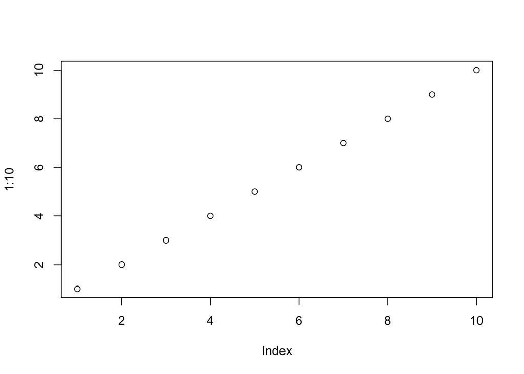

```r
library(knitr)
plot(1:10)
```